# Build Failures! Uma investigação sobre fatores que podem ocasionar falhas na *build*

Fernando Ribeiro ffribeiro@gmail.com, Moara Brito moarabritto@gmail.com, Juvenal Junior juniormacedovc@gmail.com, Luciane Meconi luciane.meconi@yahoo.com.br

06 de Agosto de 2017

### **Introdução**

A Integração Contínua (CI) é a prática de engenharia de software em que os desenvolvedores integram seu código em uma linha principal compartilhada com frequência, e verificam a qualidade de suas contribuições continuamente (BELLER, et al.,2017). De acordo com VASILESCU, et al.(2014), a CI é suportada por servidores de *build* (*e.g.**TravisTorrent*) que verificam cada integração automaticamente, executando testes de unidade e relatando os resultados de volta para os desenvolvedores. As* builds* do Travis CI apresentam os status *“passed”*, *“errored”*, *“failed”*, *“started”*, ou *“cancelled”* (MUYLAERT e DE ROOVER, 2017). RAUSCH et al (2017) afirmam que a CI melhorou os aspectos do processo de desenvolvimento de software, no entanto as *builds* com falhas representam uma ameaça para a eficiência do desenvolvimento, uma vez que ISLAM e ZIBRAN (2017), relatam que essas falhas impedem o trabalho dos desenvolvedores e atrasam o progresso do projeto.

De acordo com ISLAM e ZIBRAN (2017), os fatores que causam essas falhas devem ser identificados, pois com a identificação dos fatores os desenvolvedores podem tomar medidas cautelosas para minimizar seus impactos e, portanto, reduzir substancialmente o tempo de desenvolvimento. Após realizar um estudo da arte, foram identificados somente dois trabalhos que analisam os motivos de falhas na *build*: RAUSCH et al (2017) apresenta um estudo empírico das falhas de *build* em 14 projetos baseados em Java, e ISLAM e ZIBRAN (2017), examinam quantitativamente fatores de desenvolvimento que causam falhas de *builds* em projetos Java e Ruby. Identificamos assim uma lacuna no conhecimento sobre o que ocasiona as falhas na *build*. Dessa forma, acreditamos que esta pesquisa é importante para realizar um levantamento de novos fatores. Para isso, neste estudo investigamos três questões de pesquisa: Qp1. Projetos com maior quantidade de contribuintes tendem a ter mais falhas na *build*? QP2.O tipo de linguagem de programação influencia na geração de *build* com falhas? QP3.Rajada de mudança está mais propensas a gerar *builds* com falhas?

### **Metodologia**

Esta seção apresenta a metodologia que foi utilizada para responder às questões de pesquisa, onde foram analisados 60 projetos que usam *Travis CI* e *GitHub*, combinando ambas as fontes de dados no *TravisTorrent*. Dos projetos analisados, 30 foram desenvolvidos em linguagem Java e 30 em linguagem Ruby, totalizando 66.951 *builds*. O tratamento e análise dos dados foram realizados através da linguagem R, conforme pode ser observado na Figura 1.

[figure not shown]

Figura 1. Metodologia.

O conjunto de dados do *TravisTorrent* permitiu extrair informações sobre os projetos, status das *builds*, ids de *commits* relacionados a cada *build* e a linguagem de programação. Para obter o número de programadores, foi utilizado o *dataset* do *GitHub*, que contém o id dos *commits* e e-mails dos desenvolvedores.

##### QP1: Projetos com maior quantidade de contribuintes tendem a ter mais falhas na *build*?

SEO et al. (2014), relata que as dependências entre os membros da equipe podem ser aumentadas quando os tamanhos da equipe e do projeto são grandes, e essas dependências são suscetíveis a buids com falhas. Dessa forma, buscamos investigar se o tamanho da equipe está relacionado com a quantidade de falhas das *builds*. Logo, foram confrontadas duas hipóteses sobre as variáveis (tamanho da equipe e falhas da *build*), sendo H0 - Tamanho da equipe não está relacionado com as falhas na *build*, e H1 - O tamanho da equipe influencia na falha da *build*.

##### QP2: O tipo de linguagem de programação influencia na geração de *build* com falhas?

No *dataset* estudado, existem duas linguagens de programação, uma fortemente tipada (Java) e outra fracamente tipada (Ruby). Com essa questão (QP2), queremos saber se de fato a linguagem de programação influência na falha de *build*. Para isso, foram confrontadas duas hipóteses sobre as variáveis (linguagem de programação e falhas da *build*), sendo H0 - A linguagem de programação não está relacionada com as falhas na *build*, e H1 - A linguagem de programação influencia na falha da *build*.

Para todas as questões de pesquisa, foram utilizadas as informações das bases de dados *TravisTorrent* e *GitHub*. Essas bases possuem estruturas distintas, pois a base do *GitHub* apresenta um id de *commit* por linha e a base do *TravisTorrent* apresenta para cada *build* uma string, que contém os ids de *commits* separados por um caractere especial. Dessa forma, para agruparmos as duas bases para ser utilizada na QP1 e QP2, realizamos as seguintes etapas:

- A variável *(git_all_built_commits)* foi transformada em uma lista, onde cada elemento desta lista possui um id de *commit* único.
- Para cada elemento da lista, foi criada uma linha independente contendo o id do *commit*.
- O id do *commit* e o nome do projeto foram usados como chave de combinação entre os *datasets*.
- O *dataset* gerado a partir desta combinação foi agrupado por projeto *(gh_project_name)*. Foi calculado o número de autores a partir dos emails distintos armazenados na variavel *(author_email)* no *dataset* do *GitHub*.
- No *dataset* do *TravisTorrent* foi criada uma variável lógica, onde o *“passed”* recebeu o valor *true* e os demais foram classificados como *false*. Essa classificação foi baseada em SOUZA e SILVA (2017), onde foi classificadosucesso se seu status for “passed”, e quebra de *builds* se seu status for *“errored”*, *“failed”*, ou *“cancelled”*.
- O *dataset* do *TravisTorrent* foi agrupado por *build*, contendo o status lógico *(status_logic)*,a linguagem utilizada e o nome do projeto.
- Na sequência, os dados foram agrupados por projetos incluindo a linguagem, o número total de *builds*, o número de *builds* classificadas como *true* e a proporção de sucesso nessas *builds*.
- Foi feita uma combinação do número de autores e *status* por projeto.
- Foi criada uma variável ordinal *(n_autores_ordinal)* para armazenar o número de autores, onde os projetos foram classificados em 4 categorias (P,M,G,GG) de acordo com os quartis.
- Para armazenar as 5 categorias referente a proporção de sucesso na *build*, foi criada uma outra variável ordinal *(status_ordinal)*. Como critério, definimos aleatoriamente intervalos de 20 em 20 numa escala percentual. Ressaltamos que, outros intervalos poderiam ser escolhidos.
- Para a QP2, foi criada a variável nominal *(lang_nominal)*.

Nas variáveis numéricas da QP1, foi utilizado o teste de correlação de *Kendall* para estimar a relação entre o número de autores e a proporção de sucesso. Esse método estatístico é aplicado para testes não paramétricos, sendo apropriado quando há valores iguais e amostras pequenas. Optamos por esse teste pois nossos dados possuem as características supracitadas, conforme Figura 2. Além disso, foi aplicado o teste de *shapiro*, onde obtivemos valores de p (0.0007629 e 9.949e-11), os quais são menores do que o valor alfa(0.05) de p, indicando que os dados utilizados não possui distribuição normal.

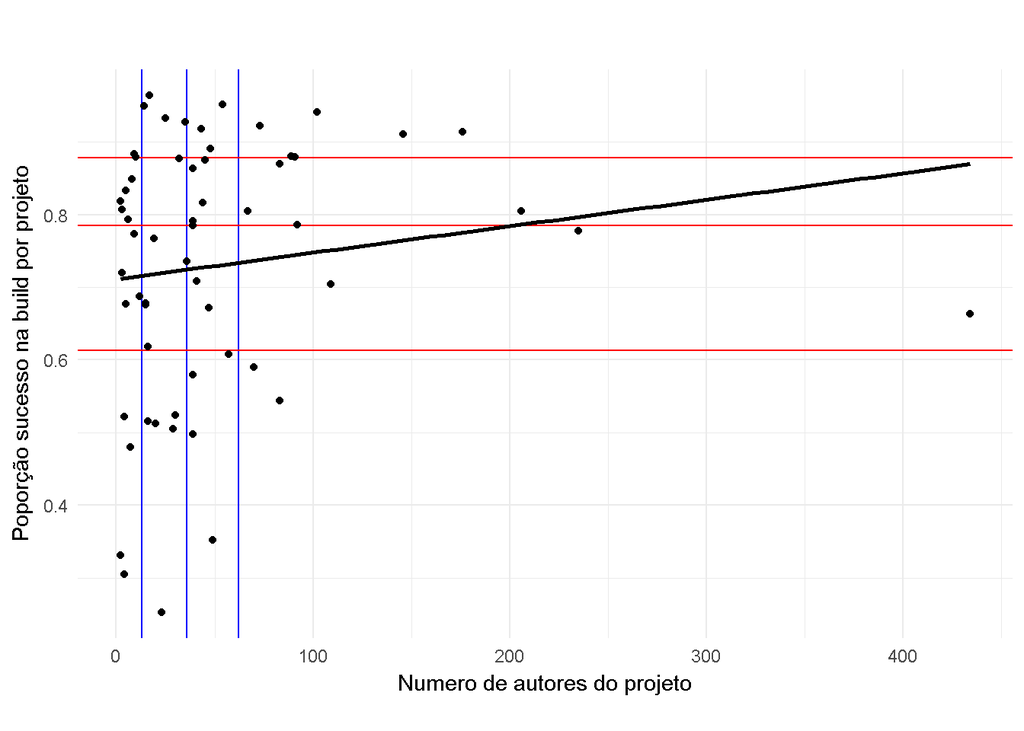

**Figura 2**. Correlação entre as variaveis (Número de autores versus proporção de sucesso na *build* por projeto). Neste gráfico, foi utilizado uma variável inteira (número de autores do projeto) no eixo x e uma variável contínua (proporção de sucesso da *build* por projeto) com variação entre 0 e 1, no eixo y. A linha de coloração preta representa a regressão linear das variáveis. As linhas verticais (azul) representam os quartis da variável número de autores do projeto (eixo x) e as linhas horizontais (vermelho) a variável proporção de sucesso da *build* (eixo y).

A partir das variáveis nominais tratadas na QP2, foi aplicado o teste de independência de qui-quadrado para avaliar a associação entre o sucesso das *builds* e a linguagem de programação. O tamanho do efeito não foi medido nessa QP, pois o resultado não foi estatisticamente significativo.

##### QP3.Rajada de mudança está mais propensa a gerar *builds* com falhas?

Nagappan et al.(2010) definiu o conceito de rajada de mudança como o número de mudanças consecutivas aplicadas em artefatos de código. Os autores mostraram que essas rajadas são excelentes indicadores de problemas de qualidade de código. Com isso, a QP3 visa investigar se a rajada de mudança contribui para a geração de falhas na *build*. Para isso, foram confrontadas duas hipóteses sobre as variáveis (rajada de mudança e falhas da *build*), sendo H0 - A rajada de mudança não está relacionada com as falhas na *build*, e H1 - A rajada de mudança influencia na falha da *build*.

A maioria dos passos realizados para o tratamento da QP1 foram aplicados ao tratamento das variáveis da Qp3. Os bancos de dados *TravisTorrent* e *GitHub* foram relacionados por meio das variáveis *commits* e projetos. As informações fornecidas pelo *GitHub* estão associadas ao tempo (datas dos *commits*), e as do *TravisTorrent* aos status das *builds*.

O grande desafio foi definir, na escala de tempo estabelecida pela data dos *commits*, quais eram os períodos de rajadas e quais não eram. Para determinar a escolha do nível e rotular os *commits*, a variável *kLevel* foi utilizada no *script*. Nesse relatório, foi definido o nível 2 para classificar as observações.

O algoritmo de *Kleinberg*, utilizado para a detecção de rajadas de mudanças implementado na biblioteca *bursts*, foi aplicado na identificação do início e fim de cada período.

Esse algoritmo, modelado como um autômato infinito, aplica estados de rajada e não rajada para períodos discretos de tempo, determinando a ocorrência da frequência (maior ou menor) dos eventos. A base para a definição, do que deve ser classificado como uma frequência de rajada ou não, é fornecida pela cadeia de *Markov*, que está baseada no funcionamento de alguns sistemas estocásticos, sendo o estado subsequente de uma cadeia de acontecimentos vinculado apenas ao seu estado atual.

A detecção do nível de rajada é outra característica fornecida pelo algoritmo de *Kleinberg*. No primeiro nível, a probabilidade de alguma frequência ser classificada como rajada é muito alta e, desta forma, toda a cadeia de eventos tende a apresentar tal classificação. A medida que os níveis aumentam, a probabilidade diminui, encerrando quando nenhuma frequência de eventos for classificada como uma rajada. Essas rajadas são detectadas em cada projeto, onde um laço percorre os bancos de dados, e seleciona os *commits* relativos a um projeto em cada passagem.

A classificação das datas dos *commits*, em rajadas e não rajadas, ocorre até o último nível em que estas podem ser detectadas. Uma variável lógica é criada para cada observação, atribuindo um valor *“true”* para rajada e um valor *“false”* para não rajada.

Após essa classificação, os dados foram relacionados com o banco de dados do *TravisTorrent*, sendo utilizados como chave, os identificadores dos *commits* e dos projetos. Os dados de cada projeto foram agrupados por *build*. As *builds* com pelo menos um *commit* marcado como rajada, foram consideradas como rajada. O tratamento para cada projeto foi armazenado em um banco de dados, inicialmente criado vazio, antes do início do laço.

O teste de qui-quadrado foi aplicado para avaliar a associação entre as duas variáveis nominais (rajadas e o status da *build*). Para medir o tamanho do efeito, utilizamos o V de Cramer, e a interpretação dos resultados foi baseada em SOUZA e SILVA (2017, apud Cohen, 1988) em que V <0,3 é considerado como efeito pequeno, V <0,5 considerado como efeito médio e V> 0,5 é considerado o tamanho de efeito grande.

Para apresentar os resultados foram utilizados os gráficos de boxplot, barras e mosaico.

### Resultados

##### A. QP1: Projetos com maior quantidade de contribuintes tendem a ter mais falhas na *build*?

Nota-se na Figura 3 a proporção de sucesso para cada uma das categoria criadas (P, M, G, GG), na qual existe uma aproximação entre a mediana de cada categoria e a mediana do conjunto, com exceção da equipe de tamanho M. Em análise das equipes de tamanhos “M”, “G” e “GG”, pode-se verificar que os valores mínimos e o primeiro quartil aumentam paralelamente ao crescimento do número de autores por projeto.

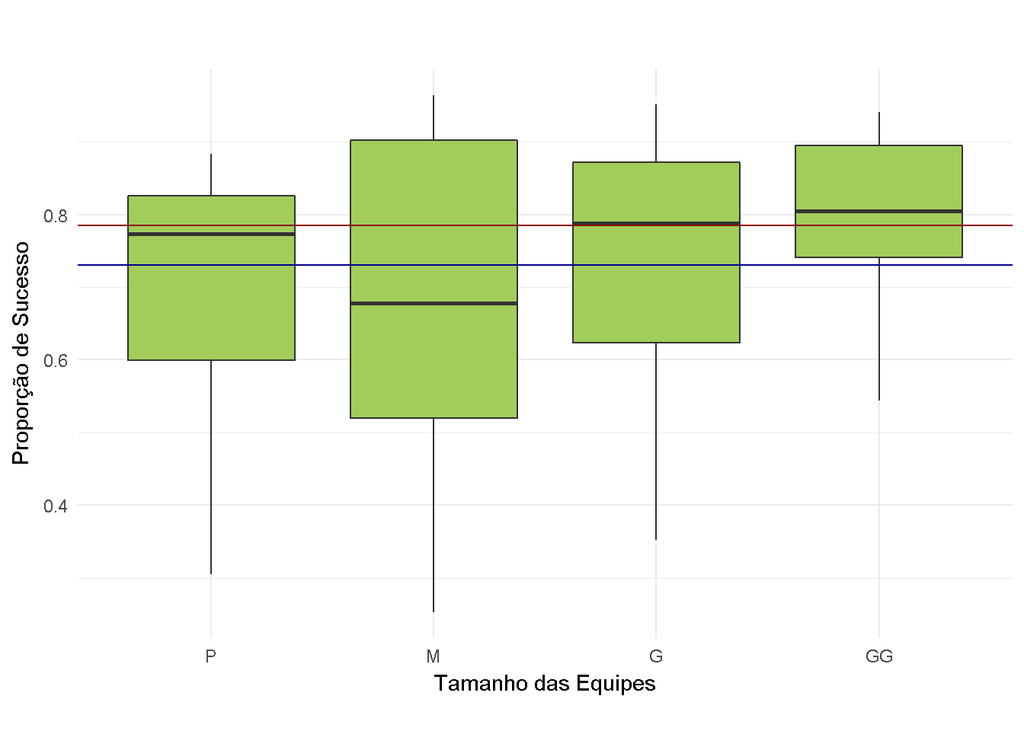

**Figura 3**. Tamanho da equipe x Sucesso da *build*. Neste gráfico, a linha azul indica a média da proporção de sucesso para os projetos e a linha vermelha, a mediana.

Os resultados observados nas Figuras 4 e 5 são semelhantes aos da Figura 3. Na Figura 4 é possível verificar que a proporção de sucesso das equipes de tamanho “M” não cresce na medida em que há um aumento no tamanho da equipe.

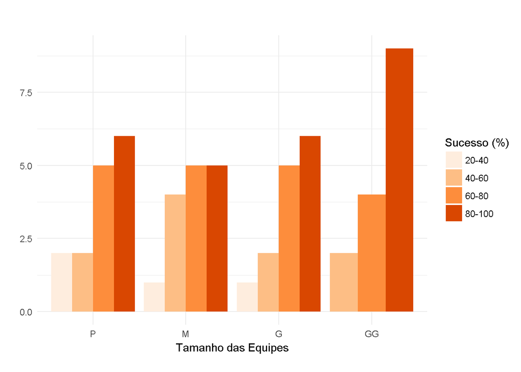

**Figura 4**. Tamanho das Equipes versus Proporção de Sucesso na *build*. A variável *proporção de sucesso da build* foi dividida em categorias distribuídas em intervalos de 20% em 20%.

Assim como na Figura 4, na Figura 5 verifica-se que as taxas entre 20-40% permanecem estáveis entre as ordens “M” e “G”, desaparecendo na ordem “GG”. A partir da ordem “M”, há um crescimento da proporção de *builds* com sucesso evidenciadas nas taxas acima de 80% e uma diminuição na faixa entre 40-60%.

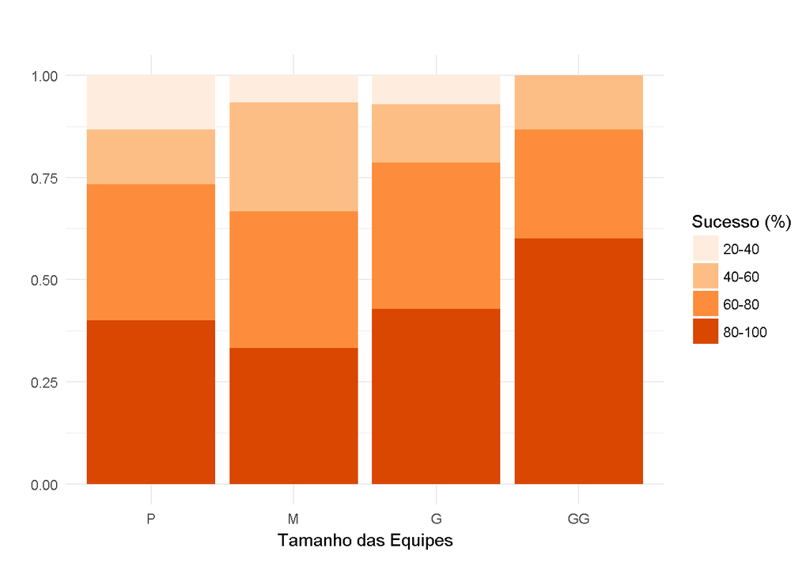

**Figura 5**. Tamanhos das Equipes x Sucesso na *build*

Os gráficos apresentados nessa questão de pesquisa (QP1), mostraram que quanto maior a quantidade de contribuintes no projeto, maior o sucesso no status da *build*.Inicialmente, poderiamos inferir que projetos com maior quantidade de contribuintes não tendem a ter mais falhas na *build*. No entanto, com base no resultado do teste de *Kendall*, utilizando O valor alfa de 0.05 (5%) como parâmetro de referência para nossa análise, o valor de *p* obtido (0.09785) é maior que o valor alfa, não existindo, assim, evidências suficientes que nos permita rejeitarmos a hipótese H0 (Tamanho da equipe não está relacionado com as falhas na *build*).

```
Dessa forma, o resultado para essa questão de pesquisa foi inconclusivo, dado que não é possível afirmar que o tamanho da equipe não influencia nas falhas da build.
```

##### B. QP2: O tipo de linguagem de programação influencia na geração de *build* com falhas?

Na Figura 6 observa-se que, os projetos em Ruby da população estudada apresentam valores mais altos para o limite inferior (desconsiderando um projeto outliner) e para o primeiro quartil, quando comparados aos projetos em Java e, ainda, um limite superior levemente acima do valor apresentado no outro grupo. O terceiro quartil dos projetos em Java tem um valor maior. A mediana dos projetos em Ruby está muito próxima da mediana geral da população. Já nos projetos em Java, a mediana aparece abaixo do valor global, sendo compensada pelo grande número de projetos com taxa de sucesso na faixa do terceiro quartil.

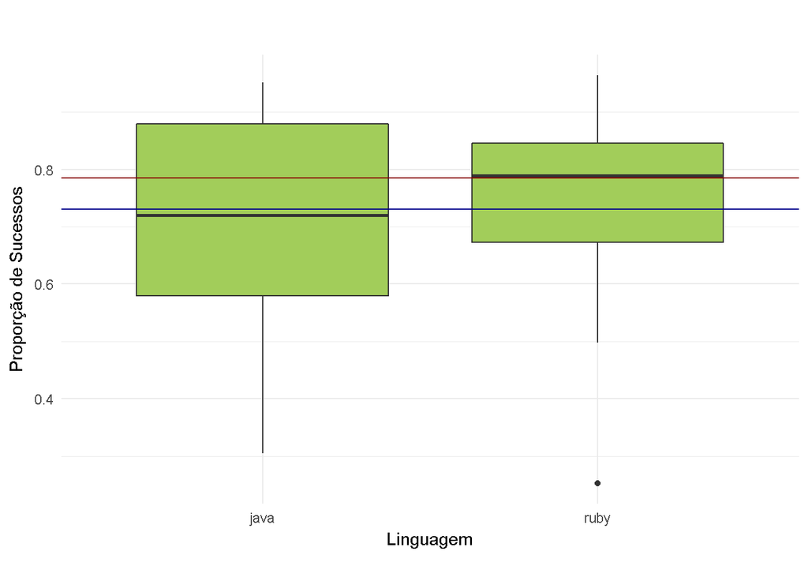

**Figura 6**. Linguagem versus Proporção de Sucesso da *build*. O gráfico boxplot apresenta no eixo X, as linguagens de programação Java e Ruby, e a proporção de sucesso da *build*, no eixo y. A linha azul define a média da proporção de sucesso para os projetos e a linha vermelha, a mediana.

Para gerar as Figuras 07 e 08 foi utilizada a variável categórica “proporção de sucesso da *build* por projeto” apresentada na QP1. Entre as faixas de sucesso 20 - 40% e 40 - 60%, a linguagem Ruby apresenta valores menores, e um valor maior na faixa entre 60 - 80%. Na faixa acima dos 80%, os valores mostram-se semelhantes nas duas linguagens.

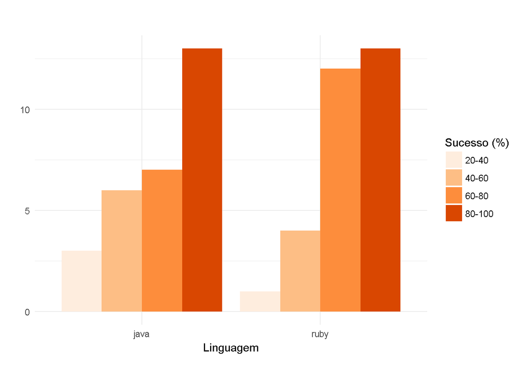

**Figura 7**. As linguagens de programação estão definidas no eixo x e as ordens da variável “proporção de sucesso da *build* por projeto” representadas em barras lado a lado para cada uma das linguagens

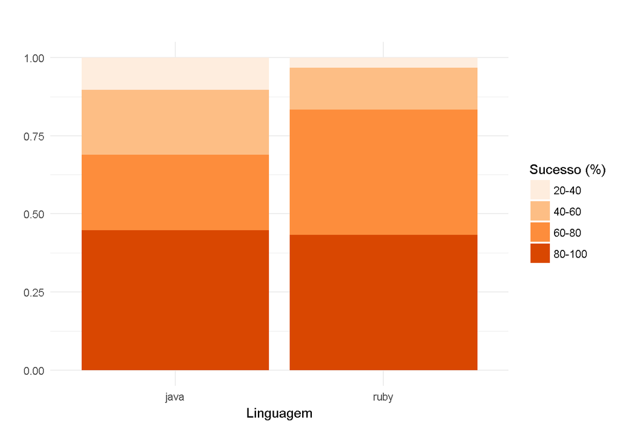

**Figura 8**. No eixo x, foram definidas as linguagens de programação e no eixo y, os valores da taxa de sucesso normalizados.

Visualizando os gráficos apresentados nessa questão, é possível ter uma sútil impressão de que os projetos desenvolvidos em linguagem ruby obtiveram maior proporção de sucesso na *build*. Porém, aplicando o teste de qui-quadrado e utilizando o mesmo valor alfa da QP1 (0.05), como parâmetro de referência, o valor de *p* obtido foi de 0.4402926, o qual é maior que o valor alfa, não existindo, assim, evidências suficientes que nos permita rejeitarmos a hipótese H0 (A linguagem de programação não está relacionada com as falhas na *build*).

```
Dessa forma, o resultado para essa questão de pesquisa foi inconclusivo, dado que não é possível afirmar que uma linguagem de programação específica está relacionada com as falhas da build.
```

##### C. QP3.Rajada de mudança está mais propensa a gerar *builds* com falhas?

Para visualizar os resultados da QP3, utilizamos um mosaico (Figura 9), que compara as duas variáveis (status da *build* e rajada). O valor mais elevado da rajada, quando comparado ao de não rajada, atribui-se a seleção do nível 2 do algoritmo de detecção, dado que a probabilidade de se classificar um período como rajada é muito alto.

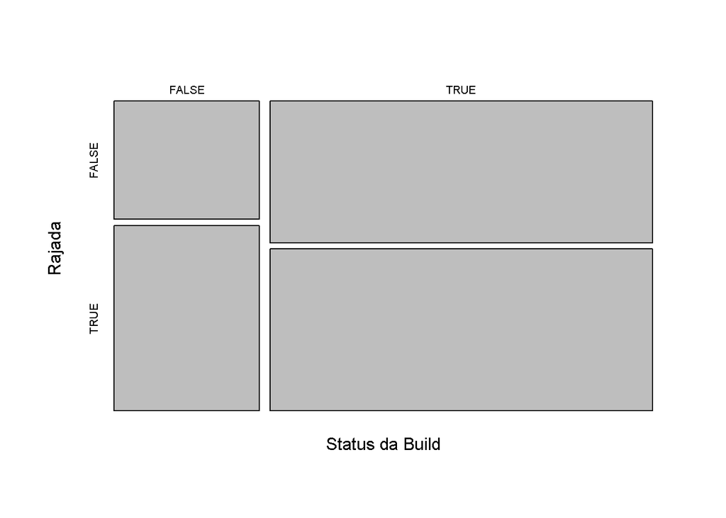

**Figura 9**. Status da Buils x Rajada. Em rajada True = É rajada e FALSE = Não é rajada. Em status da *build*, True = “passed” e False = “broken”, ou seja, que não obteve sucesso.

O resultado obtido em nossa pesquisa nos surpreendeu, pois imaginávamos, inicialmente, que as rajadas poderiam impactar negativamente no status da *build*. Desta forma, optamos por confirmar o resultado, utilizando outros níveis, dado que sua escolha foi realizada aleatoriamente.

No primeiro instante, selecionamos o nível 4, conforme pode ser observado na Figura 10, tendo como resultado que quanto menor o número de rajadas, maior o número de sucesso da *build*. Logo, diminuindo o número de rajadas, aumenta-se a proporção de sucesso da *build*. Assim, baseado nesse gráfico, podemos deduzir que a rajada de mudança está mais propensa a gerar *build* com falha. Adicionalmente, o teste do qui-quadrado mostra que a correlação entre rajadas e status da *build* é estatisticamente significativa, com p = 3.584205e-38, e com o tamanho do efeito pequeno (0.05330958).

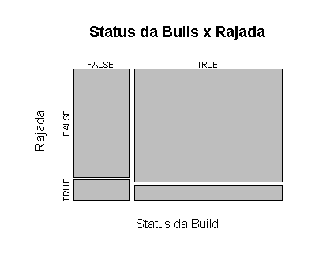

Figura 10. Status da Builds x Rajada para o nível 4.

Assim como no nível 4, o nível 8 conforme pode ser obsevado na Figura 11, demonstrou que quanto menor o número de rajada, maior o número de sucesso da *build*. No entanto, com a aplicação do teste de qui-quadro, o valor de p obtido foi igual a 0.3305786, não permitindo, assim, a rejeição da hipótese H0, responsável pela definição de que a rajada de mudança não está relacionada com as falhas na *build*.

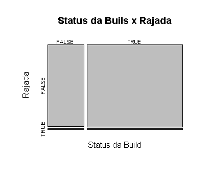

Figura 11. Status da Builds x Rajada para o nível 8.

```
Foi possível observar que a influência das rajadas de mudanças na falha da build, está diretamente relacionada ao nível escolhido como parâmetro.
```

### Conclusão

Um estudo empírico quantitativo sobre os fatores que podem ocasionar falhas nas *builds* foi apresentado neste relatório. Foram contemplados 60 projetos e 66.951 *builds* e investigadas três questões de pesquisa.

Com relação a QP1, obtivemos resultados inconclusivos, não permitindo assim, afirmar se a quantidade de contribuintes possui influência nas falhas da *build*.

Beller et al (2017) relatam que as de falhas de *builds* ocorrem com maior frequência na linguagem de programação Ruby, em nossa análise, referente a QP2, não foi possível encontrar evidências que comprovem isso.

Com relação a QP3, não foi possível concluir se, de fato, a rajada de mudança está mais propensa a gerar *builds* com falhas, uma vez que, obtivemos resultados diferentes, a partir do nível que foi definido. É de suma importância que seja realizado um estudo mais aprofundado sobre o critério de adoção do nível que definirá o conceito de rajada de mudança.

A seleção restritiva de uma amostra, contendo neste caso, apenas 60 projetos e contemplando as linguagens java e ruby, pode gerar questionamentos aos resultados obtidos. Logo, os resultados desse estudo não devem ser generalizados. Apesar da metodologia de coleta, análise e resultados dos dados estarem bem documentados neste relatório, a forma como foram definidos os valores limiares (tamanho da equipe, intervalos de proporção de sucesso e nível) também pode representar uma ameaça a validade.

No futuro, será importante a seleção de uma amostra mais ampla de projetos e de linguagens de programação, com uma melhor definição do critério de escolha do nível utilizado na caracterização de uma rajada, com o intuito de encontrar um resultado mais conclusivo.

### Referências

[1] BELLER, Moritz; GOUSIOS, Georgios; ZAIDMAN, Andy. Oops, my tests broke the build: An explorative analysis of Travis CI with GitHub. In: Proceedings of the 14th International Conference on Mining Software Repositories. IEEE Press, 2017. p. 356-367.

[2] VASILESCU, Bogdan et al. Continuous integration in a social-coding world: Empirical evidence from GitHub. In: Software Maintenance and Evolution (ICSME), 2014 IEEE International Conference on. IEEE, 2014. p. 401-405.

[3] MUYLAERT, Ward; DE ROOVER, Coen. Prevalence of botched code integrations. In: Proceedings of the 14th International Conference on Mining Software Repositories. IEEE Press, 2017. p. 503-506.

[4] RAUSCH, Thomas et al. An empirical analysis of build failures in the continuous integration workflows of Java-based open-source software. In: Proceedings of the 14th International Conference on Mining Software Repositories. IEEE Press, 2017. p. 345-355.

[5] ISLAM, Md Rakibul; ZIBRAN, Minhaz F. Insights into continuous integration build failures. In: Proceedings of the 14th International Conference on Mining Software Repositories. IEEE Press, 2017. p. 467-470.

[6] SOUZA, Rodrigo; SILVA, Bruno. Sentiment analysis of Travis CI builds. In: Proceedings of the 14th International Conference on Mining Software Repositories. IEEE Press, 2017. p. 459-462.

[7] SEO, Hyunmin et al. Programmers’ build errors: a case study (at google). In: Proceedings of the 36th International Conference on Software Engineering. ACM, 2014. p. 724-734.

[8]NAGAPPAN, Nachiappan et al. Change bursts as defect predictors. In: Software Reliability Engineering (ISSRE), 2010 IEEE 21st International Symposium on. IEEE, 2010. p. 309-318.

[9] J. Cohen, Statistical Power Analysis for the Behavioral Sciences. Lawrence Erlbaum Associates, 1988